# Functions

# Functionals

A *functional* is a special type of function in R in that, rather than simply taking data arguments, it can also take other functions. The utility of this comes when we remember the purpose of writing functions: generalize our ideas and avoid repetitive copy-and-pasting.

R comes with a number of functionals built-in, with two classes in particular worth considering here. The first is the *apply family of functions, with the second being a common set across functional programming languages

## *apply Family

The *apply family of functions in R is a collection of functions that, broadly, take two arguments: a list or vector to iterate over and a function. This makes them similar to loops in a number of ways (in fact, any apply functional can be written as a loop). The first of these we will introduce is `lapply()` or “list” apply. This works by taking a vector and a function, applying the function to each element of the vector, then returning a list of values

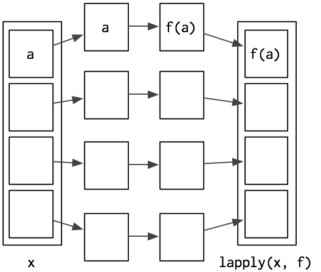

```r
knitr::include_graphics("lapply.png")
```

You can see the argument syntax with `?lapply`. The first argument will be a list or vector, the second will be a function, typically with one argument, that takes each element of the vector. Note that if I am passing in a function with a name, I simply give the name as the argument (no parenthesis or other arguments)

```r
lapply(1:5, sqrt)
```

```
## [[1]]
## [1] 1
##
## [[2]]
## [1] 1.4142
##
## [[3]]
## [1] 1.7321
##
## [[4]]
## [1] 2
##
## [[5]]
## [1] 2.2361
```

If we are using a function that takes more than two arguments by default, we can pass them in following the function (note in the documentation, this ability is represented with the `...` argument, but we need not worry about that for now)

```r
lapply(1:5, paste, "X")
```

```
## [[1]]
## [1] "1 X"
##
## [[2]]
## [1] "2 X"
##
## [[3]]
## [1] "3 X"
##
## [[4]]
## [1] "4 X"
##
## [[5]]
## [1] "5 X"
```

More commonly, though, we are writing *anonymous functions* for use with lapply. An anonymous function is simply a function without a name and works identically to how we wrote functions above

```r
lapply(1:5, function(x) x^2)
```

```
## [[1]]
## [1] 1
##
## [[2]]
## [1] 4
##
## [[3]]
## [1] 9
##
## [[4]]
## [1] 16
##
## [[5]]
## [1] 25
```

The key idea with `lapply` is that, by returning a list of objects, we are able to perform useful functions that can have complicated return values. For example, lapply on a list of file names will give us a list of data.frames

```r
## Grab the first 3
ff <- list.files("fundir/sim/", full.names = TRUE)[1:3]

df_list <- lapply(ff, read.csv)
df_list
```

```
## [[1]]
##          V1
## 1  -1.36856
## 2   0.46344
## 3   1.87452
## 4  -0.25650
## 5  -1.41324
## 6   0.83684
## 7  -0.15509
## 8   0.15707
## 9   0.19777
## 10 -0.43873
##
## [[2]]
##           V1
```

[output cut: 23 more lines]

It is an exceptionally common task to call lapply on a list of data.frames. For example, we may want to verify that each of our individual data.frames has exactly 10 observations

```r
lapply(df_list, function(x) nrow(x) == 10)
```

```
## [[1]]
## [1] TRUE
##
## [[2]]
## [1] TRUE
##
## [[3]]
## [1] TRUE
```

As a quick note, we can always “unlist” an object with the use of `unlist()`

```r
v <- lapply(1:5, function(x) x^2)
unlist(v)
```

```
## [1]  1  4  9 16 25
```

**Question 8:** Rewrite your loop from Question 4 of the previous lab so that it uses `lapply()` instead. (Note: You might wait until reviewing the `Reduce()` below for a trick on completing this more efficiently)

**Question 9:** Look at the documentation for `lapply()`. How is `sapply()` different? The code below is not run, but you can use it to investigate. Can you perform the same task with `vapply()`? See examples in the documentation if you get stuck

```r
## Create list of data
df_list <- lapply(1:5, function(x) {
  data.frame(x = rnorm(10),
             y = rnorm(10))
})

lapply(df_list, function(df) {
  cor(df$x, df$y)
})

lapply(df_list, function(df) {
  cor(df$x, df$y)
})
```

**Question 10:** The `apply()` function is slightly different than the the rest of the *apply family in that rather than taking a vector or list of objects, it operates on a matrix (a matrix is similar to a data.frame with the exception that all of the entries must be of the same type e.g., numeric or character). Use `apply()` to verify the row and column sums given below.

```r
set.seed(123)
m <- matrix(rnorm(25), nrow = 5)

## Verify these values with apply
rowSums(m)
```

```
## [1]  3.09776  0.87043 -2.29820 -0.53320 -1.97005
```

```r
colSums(m)
```

```
## [1]  0.96785 -0.22159  1.53951  0.54671 -3.66573
```

## Common Functionals in the Wild

The next set of functionals worth knowing are Reduce, Filter, Map, and Negate. You can see all of their documentation at once by viewing `?Reduce`. The most commonly used of these is `Reduce()`, which iteratively applies a binary function (a function with two arguments) to elements of a list or vector, with the option to include each of the intermediate steps. This, for example, is useful in computing a cumulative sum:

```r
Reduce(f = sum, x = 1:5, accumulate = TRUE)
```

```
## [1]  1  3  6 10 15
```

Without accumulate, it simply returns the last element, in this case, the sum of the vector

```r
Reduce(sum, 1:5)
```

```
## [1] 15
```

An extremely common use of `Reduce()` is to join a list of data.frames into a larger one

```r
library(dplyr)

df_list <- lapply(LETTERS[1:3], function(val) {
  data.frame(group = val,
             x = rnorm(5),
             y = rnorm(5))
})

df_list
```

```
## [[1]]
##   group        x        y
## 1     A -1.68669  0.42646
## 2     A  0.83779 -0.29507
## 3     A  0.15337  0.89513
## 4     A -1.13814  0.87813
## 5     A  1.25381  0.82158
##
## [[2]]
##   group         x        y
## 1     B  0.688640 -0.69471
## 2     B  0.553918 -0.20792
## 3     B -0.061912 -1.26540
## 4     B -0.305963  2.16896
## 5     B -0.380471  1.20796
##
## [[3]]
##   group         x         y
## 1     C -1.123109  0.253319
## 2     C -0.402885 -0.028547
## 3     C -0.466655 -0.042870
## 4     C  0.779965  1.368602
## 5     C -0.083369 -0.225771
```

```r
Reduce(full_join, df_list)
```

```
##    group         x         y
## 1      A -1.686693  0.426464
## 2      A  0.837787 -0.295071
## 3      A  0.153373  0.895126
## 4      A -1.138137  0.878133
## 5      A  1.253815  0.821581
## 6      B  0.688640 -0.694707
## 7      B  0.553918 -0.207917
## 8      B -0.061912 -1.265396
## 9      B -0.305963  2.168956
## 10     B -0.380471  1.207962
## 11     C -1.123109  0.253319
## 12     C -0.402885 -0.028547
## 13     C -0.466655 -0.042870
## 14     C  0.779965  1.368602
## 15     C -0.083369 -0.225771
```

Finally we briefly introduce `Map()` which works like `lapply` but is able to take any number of arguments (see the documentation for how the arguments are used). This is useful when we want to apply over several lists in sequence. Like `lapply()`, the return object is a list

```r
a <- 1:5
b <- 6:10
c <- 11:15

## Here a -> x, b -> y, and c -> z
Map(function(x, y, z) {
  (y - z)^x
}, a, b, c)
```

```
## [[1]]
## [1] -5
##
## [[2]]
## [1] 25
##
## [[3]]
## [1] -125
##
## [[4]]
## [1] 625
##
## [[5]]
## [1] -3125
```

```r
## Though for simple vectors, we can still often do directly without functionals
(b-c)^a
```

```
## [1]    -5    25  -125   625 -3125
```